[output not shown]

First, let us load the data and necessary packages:

```r
load("ames_train.Rdata")
library(MASS)
library(dplyr)
library(ggplot2)
```

# 1

Make a labeled histogram (with 30 bins) of the ages of the houses in the data set, and describe the distribution.

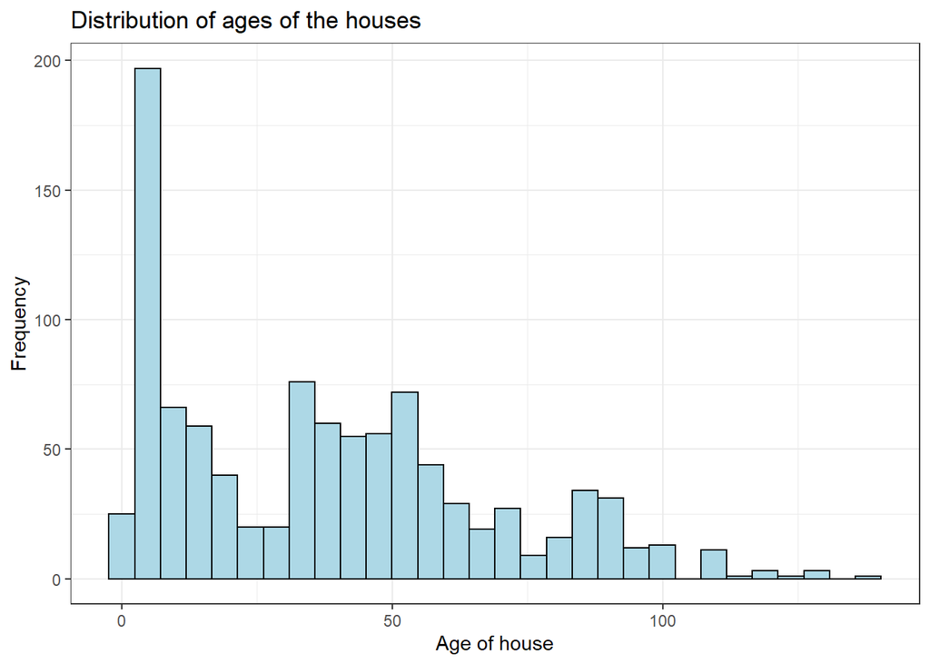

```r
ames_train <- ames_train %>%
  mutate(age = 2010 - Year.Built)

ggplot(ames_train,aes(x=age))+geom_histogram(bins=30,color="black",fill="light blue")+labs(title="Distribution of ages of the houses",x="Age of house",y="Frequency")+theme_bw()
```

As the data is for properties sold from 2006-2010, we have used 2010 as “today’s date” to calculate age of house.

We can see an overall right skew in the data, with more houses being newer rather than older. This is particularly apparent due to the second bucket in the distribution being very large. There are some smaller peaks and troughs through the data making it multi-modal, but the distribution gradually tapers off as we consider older houses.

# 2

The mantra in real estate is “Location, Location, Location!” Make a graphical display that relates a home price to its neighborhood in Ames, Iowa. Which summary statistics are most appropriate to use for determining the most expensive, least expensive, and most heterogeneous (having the most variation in housing price) neighborhoods? Report which neighborhoods these are based on the summary statistics of your choice. Report the value of your chosen summary statistics for these neighborhoods.

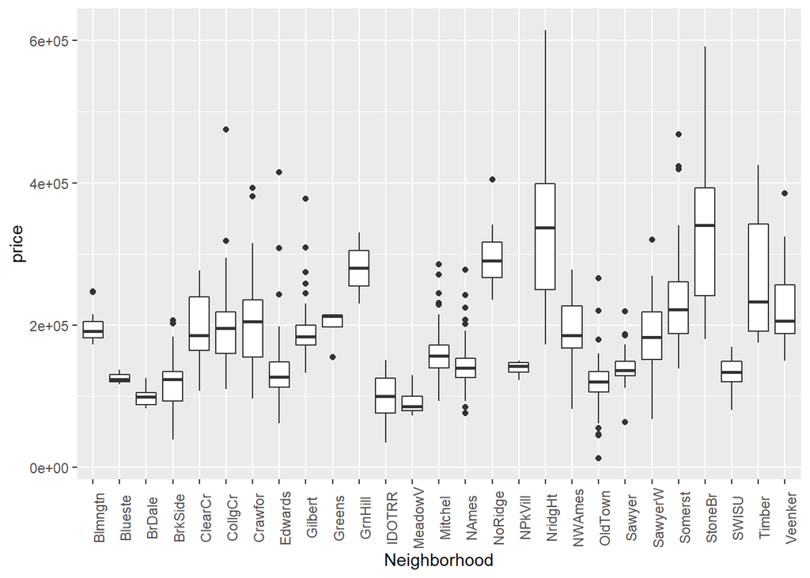

```r
ggplot(ames_train,aes(x=Neighborhood,y=price))+geom_boxplot()+theme(axis.text.x=element_text(angle=90))
```

```r
q2 <- ames_train %>%
  group_by(Neighborhood) %>%
  summarise(mean=mean(price),
            sd=sd(price),
            min = fivenum(price)[1],
            Q1 = fivenum(price)[2],
            median = fivenum(price)[3],
            Q3 = fivenum(price)[4],
            max = fivenum(price)[5])

q2
```

```
## # A tibble: 27 x 8
##    Neighborhood    mean     sd    min      Q1 median     Q3    max
##    <fct>          <dbl>  <dbl>  <dbl>   <dbl>  <dbl>  <dbl>  <dbl>
##  1 Blmngtn      198635. 26455. 172500 182112. 191000 205000 246990
##  2 Blueste      125800  10381. 116500 120200  123900 130450 137000
##  3 BrDale        98930  13338.  83000  88000   98750 105500 125500
##  4 BrkSide      122473. 37310.  39300  93000  124000 135000 207000
##  5 ClearCr      193154. 48069. 107500 164000  185000 240000 277000
##  6 CollgCr      196951. 52786. 110000 160000  195800 218836 475000
##  7 Crawfor      204197. 71268.  96500 154900  205000 235000 392500
##  8 Edwards      136322. 54852.  61500 111500  127250 148000 415000
##  9 Gilbert      193328. 41190. 133000 171500  183500 199500 377500
## 10 Greens       198562. 29063. 155000 183250  212625 213875 214000
## # ... with 17 more rows
```

For each neighborhood, we have calculated the standard 5 point summary statistics, as well as the mean and standard deviation.

Most expensive: We can see that NridgHt has the largest “max” price of 615000, but StoneBr has the largest median price of 340691.5. Therefore, on average, StoneBr is the most expensive neighbourhood.

Least expensive: We can see that OldTown has the smallest “min” price of 12789, but MeadowV has the smallest median price of 85750. Therefore, on average, MeadowV is the least expensive neighbourhood.

Most heterogeneous: Both NridgHt and StoneBr have large variation in price; NridgHt has the largest range of prices, and StoneBr has the largest interquartile range. Using standard deviation as our measure, StoneBr is the most heterogenous with a standard deviation of 123459.10.

# 3

Which variable has the largest number of missing values? Explain why it makes sense that there are so many missing values for this variable.

```r
colSums(is.na(ames_train))
```

```
##             PID            area           price     MS.SubClass       MS.Zoning
##               0               0               0               0               0
##    Lot.Frontage        Lot.Area          Street           Alley       Lot.Shape
##             167               0               0             933               0
##    Land.Contour       Utilities      Lot.Config      Land.Slope    Neighborhood
##               0               0               0               0               0
##     Condition.1     Condition.2       Bldg.Type     House.Style    Overall.Qual
##               0               0               0               0               0
##    Overall.Cond      Year.Built  Year.Remod.Add      Roof.Style       Roof.Matl
##               0               0               0               0               0
##    Exterior.1st    Exterior.2nd    Mas.Vnr.Type    Mas.Vnr.Area      Exter.Qual
##               0               0               0               7               0
##      Exter.Cond      Foundation       Bsmt.Qual       Bsmt.Cond   Bsmt.Exposure
##               0               0              21              21              21
##  BsmtFin.Type.1    BsmtFin.SF.1  BsmtFin.Type.2    BsmtFin.SF.2     Bsmt.Unf.SF
##              21               1              21               1               1
##   Total.Bsmt.SF         Heating      Heating.QC     Central.Air      Electrical
##               1               0               0               0               0
##     X1st.Flr.SF     X2nd.Flr.SF Low.Qual.Fin.SF  Bsmt.Full.Bath  Bsmt.Half.Bath
##               0               0               0               1               1
##       Full.Bath       Half.Bath   Bedroom.AbvGr   Kitchen.AbvGr    Kitchen.Qual
##               0               0               0               0               0
##   TotRms.AbvGrd      Functional      Fireplaces    Fireplace.Qu     Garage.Type
##               0               0               0             491              46
##   Garage.Yr.Blt   Garage.Finish     Garage.Cars     Garage.Area     Garage.Qual
##              48              46               1               1              47
##     Garage.Cond     Paved.Drive    Wood.Deck.SF   Open.Porch.SF  Enclosed.Porch
##              47               0               0               0               0
##     X3Ssn.Porch    Screen.Porch       Pool.Area         Pool.QC           Fence
##               0               0               0             997             798
##    Misc.Feature        Misc.Val         Mo.Sold         Yr.Sold       Sale.Type
##             971               0               0               0               0
##  Sale.Condition             age
##               0               0
```

Pool.QC is the variable with the most missing values: 997 missing values. This is because these houses do not have a pool and therefore do not have a pool quality score This tells us that 3 houses in the dataset do have a pool.

# 4

We want to predict the natural log of the home prices. Candidate explanatory variables are lot size in square feet (Lot.Area), slope of property (Land.Slope), original construction date (Year.Built), remodel date (Year.Remod.Add), and the number of bedrooms above grade (Bedroom.AbvGr). Pick a model selection or model averaging method covered in the Specialization, and describe how this method works. Then, use this method to find the best multiple regression model for predicting the natural log of the home prices.

```r
sub_ames <- ames_train %>%
  dplyr::select(price, Lot.Area, Land.Slope, Year.Built, Year.Remod.Add, Bedroom.AbvGr) %>%
  mutate(price = log(price))

lm <- lm(price ~ . - price, data = sub_ames)

n <- length(sub_ames$price)
k <- log(n)

ames_full_step <- stepAIC(lm, k=k, data =sub_ames)
```

```
## Start:  AIC=-2511.42
## price ~ (Lot.Area + Land.Slope + Year.Built + Year.Remod.Add +
##     Bedroom.AbvGr) - price
##
##                  Df Sum of Sq    RSS     AIC
## <none>                        77.322 -2511.4
## - Land.Slope      2    1.4281 78.750 -2506.9
## - Bedroom.AbvGr   1    5.0628 82.385 -2454.9
## - Lot.Area        1    6.7292 84.051 -2434.9
## - Year.Remod.Add  1   11.9642 89.286 -2374.5
## - Year.Built      1   19.8546 97.177 -2289.8
```

```r
summary(ames_full_step)
```

```
##
## Call:
## lm(formula = price ~ (Lot.Area + Land.Slope + Year.Built + Year.Remod.Add +
##     Bedroom.AbvGr) - price, data = sub_ames)
##
## Residuals:
##     Min      1Q  Median      3Q     Max
## -2.0878 -0.1651 -0.0211  0.1657  0.9945
##
## Coefficients:
##                  Estimate Std. Error t value Pr(>|t|)
## (Intercept)    -1.371e+01  8.574e-01 -15.996  < 2e-16 ***
## Lot.Area        1.028e-05  1.106e-06   9.296  < 2e-16 ***
## Land.SlopeMod   1.384e-01  4.991e-02   2.773  0.00565 **
## Land.SlopeSev  -4.567e-01  1.514e-01  -3.016  0.00263 **
## Year.Built      6.049e-03  3.788e-04  15.968  < 2e-16 ***
## Year.Remod.Add  6.778e-03  5.468e-04  12.395  < 2e-16 ***
## Bedroom.AbvGr   8.686e-02  1.077e-02   8.063 2.12e-15 ***
## ---
## Signif. codes:  0 '***' 0.001 '**' 0.01 '*' 0.05 '.' 0.1 ' ' 1
##
## Residual standard error: 0.279 on 993 degrees of freedom
## Multiple R-squared:  0.5625, Adjusted R-squared:  0.5598
## F-statistic: 212.8 on 6 and 993 DF,  p-value: < 2.2e-16
```

```r
BIC(ames_full_step)
```

```
## [1] 333.3642
```

We have started with the model including all candidate variables and used stepwise functioning to step through the model, removing variables iteratively to improve the fit. We can see that the best model is actually to include all 5 candidate variables, as they all add value to the fit and so removing any of them will weaken the fit. We could further investigate for colinearity, or if some variables have very small added value and if it would make sense to remove them for a more parsimonious model.

BIC is calculated as log(n)k − 2 log(L). The preferred model is the one with the minimum BIC. Our model gives a BIC of 333.3642.

# 5

Which home has the largest squared residual in the previous analysis (Question 4)? Looking at all the variables in the data set, can you explain why this home stands out from the rest (what factors contribute to the high squared residual and why are those factors relevant)?

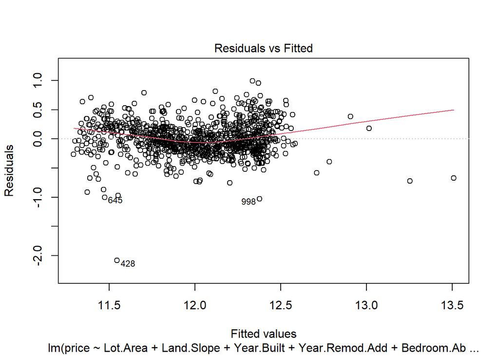

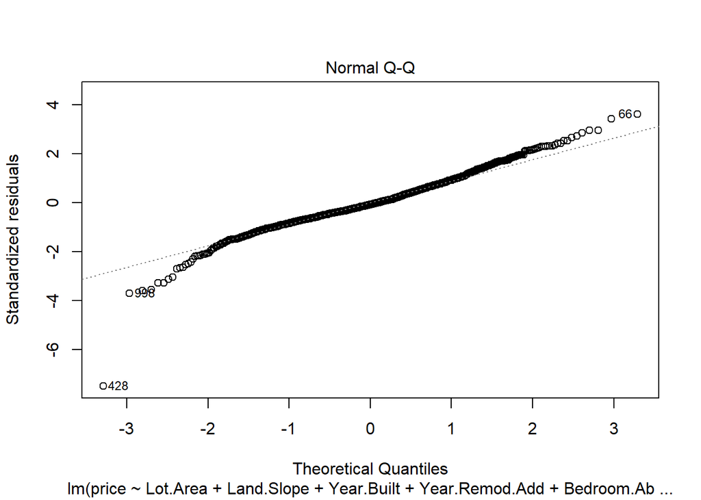

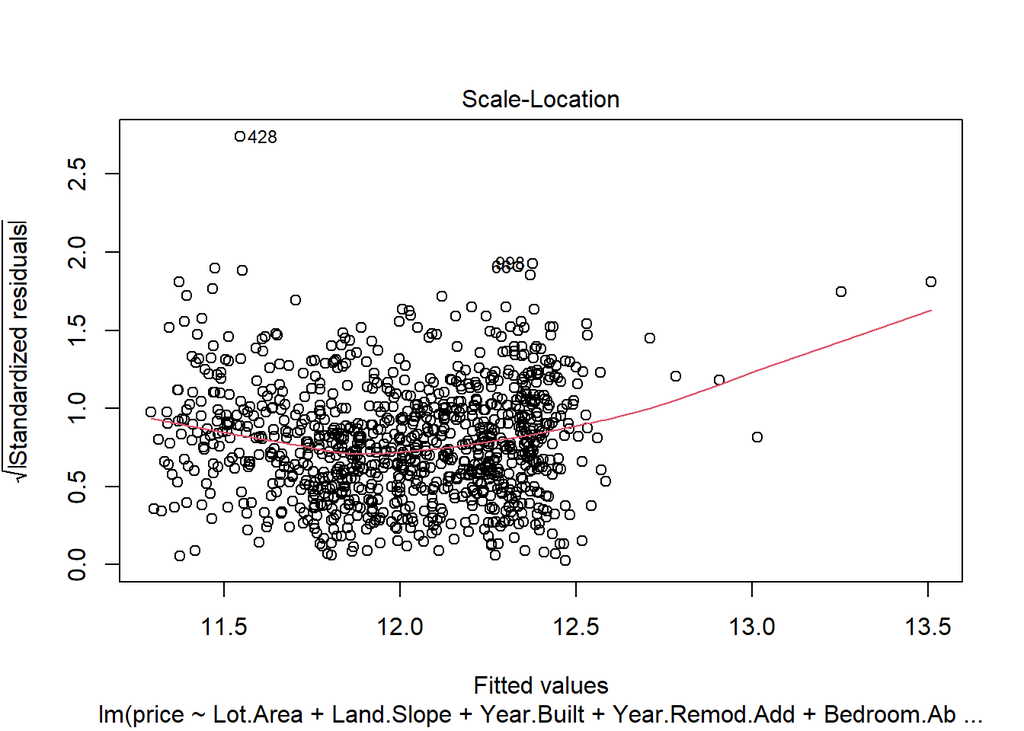

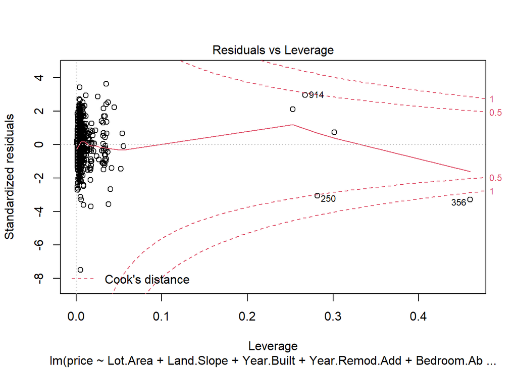

```r
model_final <- lm(price ~ Lot.Area + Land.Slope + Year.Built + Year.Remod.Add + Bedroom.AbvGr, data = sub_ames)
plot(model_final)
```

```r
x <- lm[["residuals"]]

x <- sort(desc(abs(x)))

x
```

[output not shown]

[output cut: 345 more lines]

[output not shown]

We can see in the “Residuals vs Fitted” plot that house 428 in our data has the largest squared residual, which is PID 902207130. The house sold for only 12,789. This is surprisingly low given the lot size and number of bedrooms.

# 6

Use the same model selection method you chose in Question 4 to again find the best multiple regression model to predict the natural log of home prices, but this time **replacing Lot.Area with log(Lot.Area)**. Do you arrive at a model including the same set of predictors?

```r
sub_ames2 <- sub_ames %>%
  mutate(Lot.Area = log(Lot.Area))

lm2 <- lm(price ~ . - price, data = sub_ames2)

n <- length(sub_ames$price)
k <- log(n)

ames_full_step <- stepAIC(lm2, k=k, data =sub_ames2)
```

```
## Start:  AIC=-2615.14
## price ~ (Lot.Area + Land.Slope + Year.Built + Year.Remod.Add +
##     Bedroom.AbvGr) - price
##
##                  Df Sum of Sq    RSS     AIC
## - Land.Slope      2    0.4429 70.147 -2622.6
## <none>                        69.704 -2615.1
## - Bedroom.AbvGr   1    2.2002 71.904 -2591.0
## - Year.Remod.Add  1   11.8182 81.522 -2465.4
## - Lot.Area        1   14.3474 84.051 -2434.9
## - Year.Built      1   19.4083 89.112 -2376.4
##
## Step:  AIC=-2622.62
## price ~ Lot.Area + Year.Built + Year.Remod.Add + Bedroom.AbvGr
##
##                  Df Sum of Sq    RSS     AIC
## <none>                        70.147 -2622.6
## - Bedroom.AbvGr   1    2.0816 72.228 -2600.3
## - Year.Remod.Add  1   11.9455 82.092 -2472.3
## - Lot.Area        1   15.7256 85.872 -2427.3
## - Year.Built      1   19.3032 89.450 -2386.4
```

```r
summary(ames_full_step)
```

```
##
## Call:
## lm(formula = price ~ Lot.Area + Year.Built + Year.Remod.Add +
##     Bedroom.AbvGr, data = sub_ames2)
##
## Residuals:
##      Min       1Q   Median       3Q      Max
## -2.14609 -0.15825 -0.01477  0.15354  1.01578
##
## Coefficients:
##                  Estimate Std. Error t value Pr(>|t|)
## (Intercept)    -1.557e+01  8.213e-01 -18.964  < 2e-16 ***
## Lot.Area        2.471e-01  1.654e-02  14.935  < 2e-16 ***
## Year.Built      5.964e-03  3.604e-04  16.547  < 2e-16 ***
## Year.Remod.Add  6.765e-03  5.197e-04  13.017  < 2e-16 ***
## Bedroom.AbvGr   5.726e-02  1.054e-02   5.434 6.94e-08 ***
## ---
## Signif. codes:  0 '***' 0.001 '**' 0.01 '*' 0.05 '.' 0.1 ' ' 1
##
## Residual standard error: 0.2655 on 995 degrees of freedom
## Multiple R-squared:  0.6031, Adjusted R-squared:  0.6015
## F-statistic: 377.9 on 4 and 995 DF,  p-value: < 2.2e-16
```

```r
BIC(ames_full_step)
```

```
## [1] 222.1599
```

Using log(Lot.Area), we arrive at a different model. The Land.Slope variable has been dropped and the fit has improved, to give a BIC of 222.1599.

# 7

Do you think it is better to log transform Lot.Area, in terms of assumptions for linear regression? Make graphs of the predicted values of log home price versus the true values of log home price for the regression models selected for Lot.Area and log(Lot.Area). Referencing these two plots, provide a written support that includes a quantitative justification for your answer in the first part of question 7.

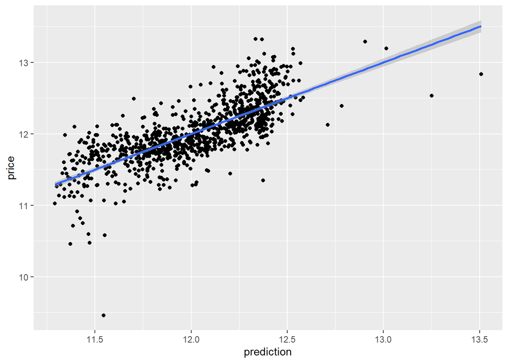

```r
prediction <- predict(lm, sub_ames)
ggplot(sub_ames,aes(prediction,price))+geom_point()+geom_smooth(method="lm")
```

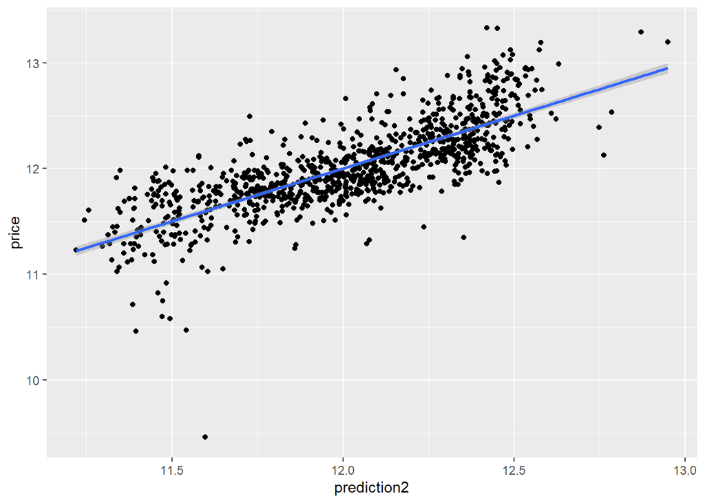

```r
prediction2 <- predict(lm2, sub_ames2)
ggplot(sub_ames2,aes(prediction2,price))+geom_point()+geom_smooth(method="lm")
```

As the model with log transformed Lot.Area improves the BIC from 333.3642 to 222.1599, and improves the fit of the model, reducing the residual mean square error as can be seen in the above scatter plots, I think that log transforming Lot.Area improves the multiple regression model.